# R Notebook

Ronald W Buie

```r
knitr::opts_chunk$set(fig.show = "all", results = "hide")
```

# Instructions: You may discuss the homework problems in small groups, but you must write up the .nal solutions and code yourself. Please turn in your code for the problems that involve coding. However, code without written answers will receive no credit. To receive credit, you must explain your answers and show your work. All plots should be appropriately labeled and legible, with axis labels, legends, etc., as needed.

# 1. In this problem, you will generate data with p = 2 features and a qualitative response with K = 3 classes, and n = 50 observations per class. You will then apply linear discriminant analysis to the data.

## (a) Generate data such that the distribution of an observation in the kth class follows a N(?k, S) distribution, for k =1,…,K. That is, the data follow a bivariate normal distribution with a mean vector ?k that is speci.c to the kth class, and a covariance matrix S that is shared across the K classes. Choose S and ?1,…,?K such that there is some overlap between the K classes, i.e. no linear decision boundary is able to perfectly separate the training data. Specify your choices for S and ?1,…,?K .

```r
set.seed(990)
DOTDISTANCE <- 4
STANDARDDEV <- 3
findit <- function(length,angle,coord) {
  #not sure what I'm doing wrong, but x and y work when reverse, so here goes
  #Error, at 180 degrees, a very small number is reported, instead of 0
  if(coord == "x") {
    toReturn <- length*sin(angle*(pi/180))
  }
  if(coord == "y") {
    toReturn <- length*cos(angle*(pi/180))
  }
  return(toReturn)
}
findit(5,45,"x")
```

```
[1] 3.535534
```

```r
DF <- data.frame(X1 = c(rnorm(50,0,STANDARDDEV),
                        rnorm(50,findit(DOTDISTANCE,120,"x"),STANDARDDEV),
                        rnorm(50,findit(DOTDISTANCE,240,"x"),STANDARDDEV)) ,
                 X2=  c(rnorm(50,DOTDISTANCE,STANDARDDEV),
                        rnorm(50,findit(DOTDISTANCE,120,"y"),STANDARDDEV),
                        rnorm(50,findit(DOTDISTANCE,240,"y"),STANDARDDEV)) ,
                 Type = (c(rep(1,50),rep(2,50),rep(3,50) )))
```

3 sets of 50 points were created with mean locations equidistat from the origin (0,0) and at even angles (0, 120, and 240 degrees). Each set of 50 points exists 3 standard deviations from their central mean.

## (b) Plot the data, with the observations in each class displayed in a di.erent color. Compute and display the Bayes decision boundary (or Bayes de?cision boundaries) on this plot. This plot should look something like the right-hand panel of Figure 4.6 in the textbook (although no need to worry about shading the background, and also you don?t need to display the LDA decision boundary for this sub-problem ? you will do that in the next sub-problem). Be sure to label which region(s) of the plot correspond to each class.

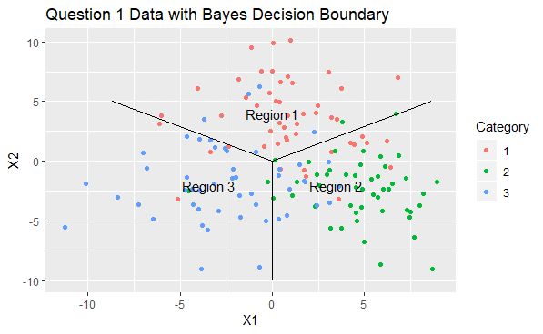

```r
library(ggplot2)
linelength <- 10
ggplot(DF, aes(x = X1,y=X2, color=as.factor(Type))) +
  geom_point() +
  ggtitle("Question 1 Data with Bayes Decision Boundary") +
  labs(colour= "Category")+
  geom_segment(aes(x=0, y=0, xend = 0, yend = findit(linelength,180,"y")), color = "black") +
  geom_segment(aes(x=0, y=0, xend = findit(linelength,300,"x"), yend=findit(linelength,300,"y")), color = "black") +
  geom_segment(aes(x=0, y=0, xend = findit(linelength,60,"x"), yend=findit(linelength,60,"y")), color = "black") +
  annotate(geom = "text", x= 0, y = DOTDISTANCE, label = "Region 1") +
  annotate(geom = "text",x = findit(DOTDISTANCE,120,"x"), y=findit(DOTDISTANCE,120,"y"),  label= "Region 2") +
  annotate(geom = "text",x = findit(DOTDISTANCE,240,"x"), y=findit(DOTDISTANCE,240,"y"),  label= "Region 3")
```

## (c) Fit a linear discriminant analysis model to the data, and make a plot that displays the observations as well as the decision boundary (or boundaries) corresponding to this .tted model. How does the LDA decision boundary (which can be viewed as an estimate of the Bayes decision boundary) compare to the Bayes decision boundary that you computed and plotted in (b)?

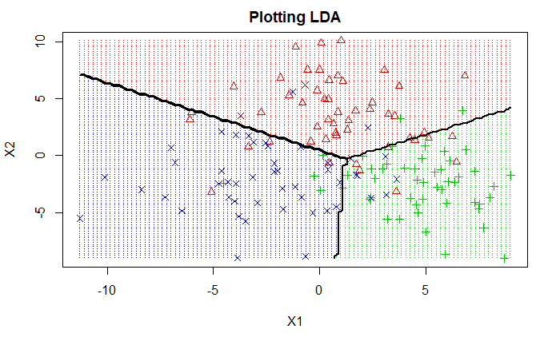

```r
library(MASS)
#this function adopted from Michael Hahsler
#http://michael.hahsler.net/SMU/EMIS7332/R/viz_classifier.html
decisionplot <- function(model, data, class = NULL, predict_type = "class",
  resolution = 100, showgrid = TRUE, ...) {
  if(!is.null(class)) cl <- data[,class] else cl <- 1
  data <- data[,1:2]
  k <- length(unique(cl))
  plot(data, col = as.integer(cl)+1L, pch = as.integer(cl)+1L, ...)
  # make grid
  r <- sapply(data, range, na.rm = TRUE)
  xs <- seq(r[1,1], r[2,1], length.out = resolution)
  ys <- seq(r[1,2], r[2,2], length.out = resolution)
  g <- cbind(rep(xs, each=resolution), rep(ys, time = resolution))
  colnames(g) <- colnames(r)
  g <- as.data.frame(g)
  ### guess how to get class labels from predict
  ### (unfortunately not very consistent between models)
  p <- predict(model, g, type = predict_type)
  if(is.list(p)) p <- p$class
  p <- as.factor(p)
  if(showgrid) points(g, col = as.integer(p)+1L, pch = ".")
  z <- matrix(as.integer(p), nrow = resolution, byrow = TRUE)
  contour(xs, ys, z, add = TRUE, drawlabels = FALSE,
    lwd = 2, levels = (1:(k-1))+.5)
  invisible(z)
}
test <- lda(Type~., data = DF)
decisionplot(test, DF, class = "Type",main = "Plotting LDA")
```

The LDA decision boundaries are similar, but not geometric. The boundaries on the positive Y axis are less acute reltaive to each other, and the boundary on the negative y axis is no longer perfectly vertical.